# Practical Sheet 5 Solutions

We have the data

```
x=c(8.3, 8.3, 12.1, 12.1, 17, 17, 17, 24.3, 24.3, 24.3, 33.6)
y=c(227, 312, 362, 521, 640, 539, 728, 945, 738, 759, 1263)
```

We can plot this data

```
plot(y~x)
```

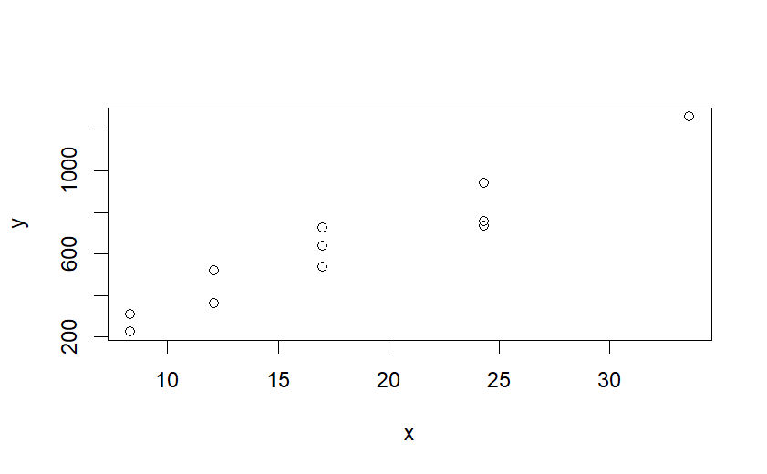

We can use the ``linear model’’ command lm(y~x) to find the regression line of $y$ on $x$:

```
regress=lm(y~x)
```

This gives us the model
$$\hat{y}=36.18 x-12.84$$

```
summary(regress)
```

```
Call:
lm(formula = y ~ x)

Residuals:
    Min      1Q  Median      3Q     Max
-128.43  -63.13   24.52   69.32  125.72

Coefficients:
            Estimate Std. Error t value Pr(>|t|)
(Intercept)  -12.842     72.143  -0.178    0.863
x             36.184      3.693   9.798 4.24e-06 ***
---
Signif. codes:  0 ‘***’ 0.001 ‘**’ 0.01 ‘*’ 0.05 ‘.’ 0.1 ‘ ’ 1

Residual standard error: 92.19 on 9 degrees of freedom
Multiple R-squared:  0.9143,    Adjusted R-squared:  0.9048
F-statistic: 96.01 on 1 and 9 DF,  p-value: 4.239e-06
```

There is no evidence that the intercept term is not equal to zero ($p$-value is $0.863$), but there is overwhelming evidence that the gradient term is not equal to zero ($p$-value $4.24 \times 10^{-6}$).

We can add the estimated line to our plot as follows:

```
plot(y~x)
abline(lm(y~x))
```

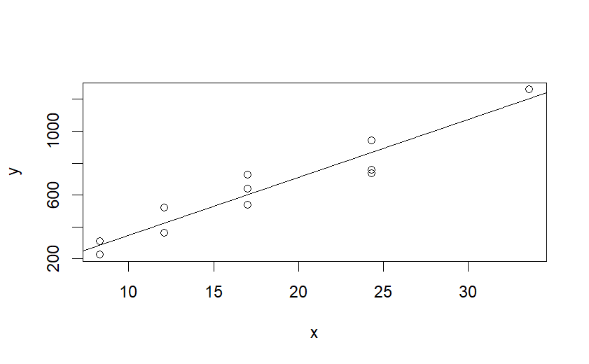

```
residuals(regress)
```

```
         1          2          3          4          5          6
 -60.48439   24.51561  -62.98301   96.01699   37.71613  -63.28387
         7          8          9         10         11
 125.71613   78.57404 -128.42596 -107.42596   60.06426
```

```
plot(residuals(regress)~x)
```

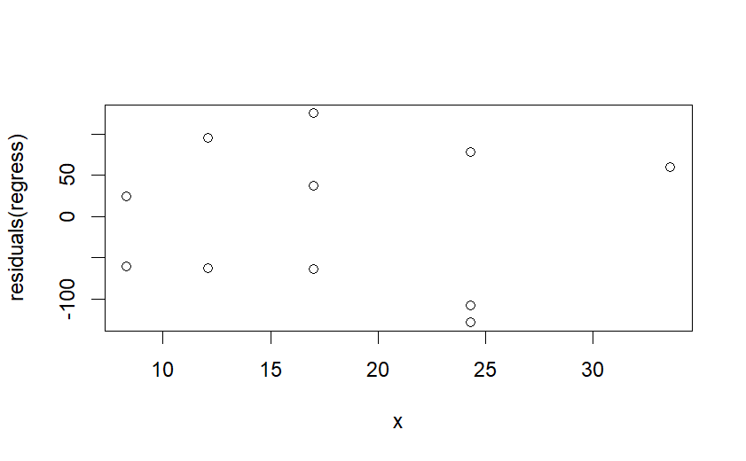

The residuals seem fairly random so the regression model is good.

Next we can look at the correlation coefficient

```
cor(x,y)
```

```
[1] 0.9561852
```

The correlation coefficient is $0.9561852$ so there is a very strong positive association between $x$ and $y$.

```
predict(regress,data.frame(x=26.0),interval="confidence",level=0.95)
```

```
       fit      lwr      upr
1 927.9385 836.3418 1019.535
```

```
predict(regress,data.frame(x=26.0),interval="prediction",level=0.95)
```

```
       fit      lwr      upr
1 927.9385 700.1596 1155.717
```

### Question 2

```
lift=c(1.9,3.3,1.2,4.2,1.5,2.2,1.0,5.6,1.9,3.8)
visitor=c(15.1,22.6,9.2,37.5,8.9,21.1,5.8,41.0,9.2,32.4)
```

```
cor(lift,visitor)
```

```
[1] 0.9660591
```

```
plot(lift,visitor)
```

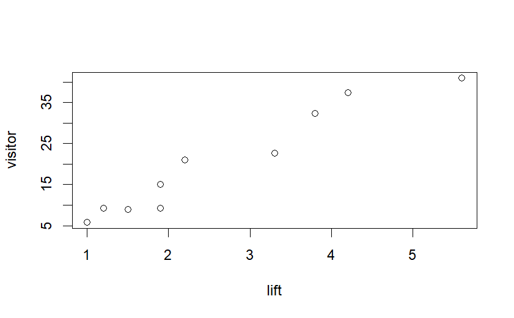

The graph shows a strong positive linear association between $x$ and $y$, the value of $r=0.966$ is close to $1$ so confirms this.

```
lm(visitor~lift)
```

```
Call:
lm(formula = visitor ~ lift)

Coefficients:
(Intercept)         lift
     -1.725        8.273
```

The equation of the least squares line is
$$\hat{y}=8.273 x -1.725$$

```
plot(lift,visitor)
abline(lm(visitor~lift))
```

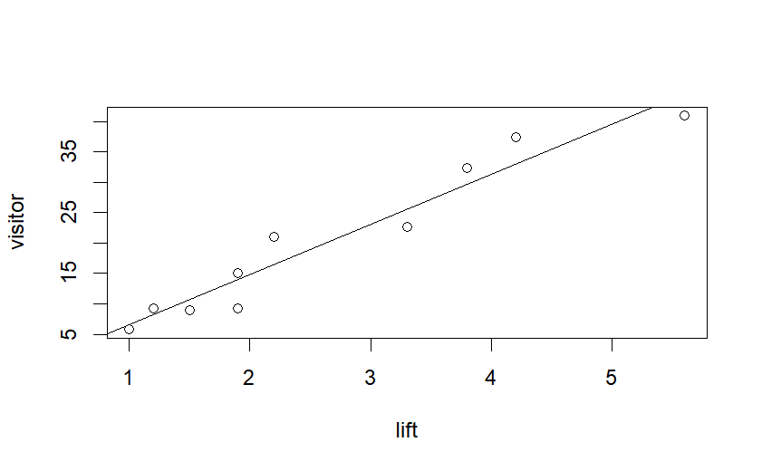

```
plot(residuals(lm(visitor~lift))~fitted.values(lm(visitor~lift)))
```

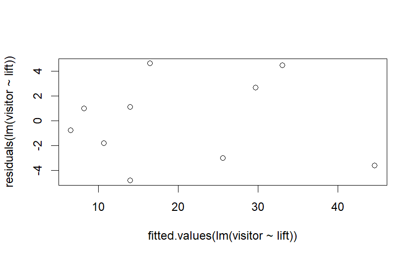

The plot is fairly random so the regression equation is good.